# Airport Waiting Times

Bret Larget

This R Markdown document includes contributions from Professor Jessi Kehe.

## Function to read in waiting time data

```r
## Input:  x = HTML file
## Output: nicely formatted tibble
read_airport =  function(x)
{
  airport_column_names = c("airport",
                           "terminal",
                           "date",
                           "hour",
                           "us_avg_wait",
                           "us_max_wait",
                           "non_us_avg_wait",
                           "non_us_max_wait",
                           "all_avg_wait",
                           "all_max_wait",
                           "all_n_0_15",
                           "all_n_16_30",
                           "all_n_31_45",
                           "all_n_46_60",
                           "all_n_61_90",
                           "all_n_91_120",
                           "all_n_120_plus",
                           "all_excluded",
                           "all_total",
                           "all_flights",
                           "all_booths")

  airport = readHTMLTable(x)$`NULL` %>%
    slice(-(1:3))

  names(airport) = airport_column_names

  airport = airport %>%
    as_tibble() %>%
    mutate(across(ends_with("wait") | starts_with("all"), as.numeric)) %>%
    mutate(across(where(is.factor),as.character)) %>%
    mutate(date = mdy(date))

  return( airport )
}
```

## Read the Data

```r
## read the individual data sets
den = read_airport("../../data/DEN-2018.html")
jfk = read_airport("../../data/JFK-2018.html")
lax = read_airport("../../data/LAX-2018.html")
msp = read_airport("../../data/MSP-2018.html")
ord = read_airport("../../data/ORD-2018.html")
sfo = read_airport("../../data/SFO-2018.html")

## combine into one data set
awt = bind_rows(den, jfk, lax, msp, ord, sfo)

## remove the individual ones
rm(den, jfk, lax, msp, ord, sfo)
```

## Exploratory Data Analysis

### Any missing data?

- In the next chunk, we create a function that counts the number of missing values in a vector
- We then use `across()` inside of `summarize()` to count the missing data in each variable.

```r
count_na = function(x)
{
  return ( sum(is.na(x) ) )
}

awt %>%
  summarize(across(everything(), count_na)) %>%
  print(width = Inf)
```

```
## # A tibble: 1 × 21
##   airport terminal  date  hour us_avg_wait us_max_wait non_us_avg_wait
##     <int>    <int> <int> <int>       <int>       <int>           <int>
## 1       0        0     0     0           0           0               0
##   non_us_max_wait all_avg_wait all_max_wait all_n_0_15 all_n_16_30 all_n_31_45
##             <int>        <int>        <int>      <int>       <int>       <int>
## 1               0            0            0          0           0           0
##   all_n_46_60 all_n_61_90 all_n_91_120 all_n_120_plus all_excluded all_total
##         <int>       <int>        <int>          <int>        <int>     <int>
## 1           0           0            0              0            0         0
##   all_flights all_booths
##         <int>      <int>
## 1           0          0
```

```r
# There are no missing values for any variables.
```

### Lambda functions

- `across()` also allows one to define a function within the call rather than creating and naming it beforehand
- one way to do so is using a concept from other computer programming languages called a *lambda function*
  - a lambda function is a small “anonymous” function, meaning it is not named
  - it also can only have a single input
  - the lambda function is defined, used once, and discarded
- In `across()` the syntax for specifying a lambda function is to start with the tilde (`~`) and then follow with the function definition
  - `.x` is the single input argument, and stands for here as the values in a single column
- See the example below.

```r
awt %>%
  summarize(across(everything(), ~ sum(is.na(.x)))) %>%
  print(width = Inf)
```

```
## # A tibble: 1 × 21
##   airport terminal  date  hour us_avg_wait us_max_wait non_us_avg_wait
##     <int>    <int> <int> <int>       <int>       <int>           <int>
## 1       0        0     0     0           0           0               0
##   non_us_max_wait all_avg_wait all_max_wait all_n_0_15 all_n_16_30 all_n_31_45
##             <int>        <int>        <int>      <int>       <int>       <int>
## 1               0            0            0          0           0           0
##   all_n_46_60 all_n_61_90 all_n_91_120 all_n_120_plus all_excluded all_total
##         <int>       <int>        <int>          <int>        <int>     <int>
## 1           0           0            0              0            0         0
##   all_flights all_booths
##         <int>      <int>
## 1           0          0
```

### Summarize Key Variables

> How many passengers and flights are there at each airport/terminal combination?

```r
## airports and terminals
awt %>%
  group_by(airport,terminal) %>%
  summarize(passengers = sum(all_total),
            flights = sum(all_flights))
```

```
## # A tibble: 16 × 4
## # Groups:   airport [6]
##    airport terminal                           passengers flights
##    <chr>   <chr>                                   <dbl>   <dbl>
##  1 DEN     International                         1032579    5815
##  2 JFK     Terminal 1                            3863833   14522
##  3 JFK     Terminal 4 (IAT)                      6606351   32839
##  4 JFK     Terminal 5 (Jet Blue)                 1605432   10638
##  5 JFK     Terminal 7 (British)                  1750517    8536
##  6 JFK     Terminal 8 (American)                 1996535    9628
##  7 LAX     Satellite 2                            796057    6539
##  8 LAX     Satellite 5                              5357     527
##  9 LAX     Satellite 7                            770716    5958
## 10 LAX     Terminal 4                             353672    2925
## 11 LAX     Tom Bradley International Terminal    9801130   45055
## 12 MSP     Terminal 1Lindbergh                    757179    4533
## 13 MSP     Terminal 2Humphrey                     243953    4567
## 14 ORD     Terminal 5                            5601907   29529
## 15 SFO     Terminal A                            2744262   11975
## 16 SFO     Terminal G                            3501690   15480
```

```r
### JFK and LAX have five different international terminals
### The other airports have one or two each.
```

> How many days of data are there for each airport?

```r
## examine date by airport
awt %>%
  select(airport,date) %>%
  distinct() %>%
  count(airport)
```

```
## # A tibble: 6 × 2
##   airport     n
##   <chr>   <int>
## 1 DEN       364
## 2 JFK       364
## 3 LAX       364
## 4 MSP       364
## 5 ORD       364
## 6 SFO       364
```

```r
## One date is missing for all the airports
```

- One day is missing for each airport! Can we figure out which one it is?
- One approach could be to narrow down by:
  - adding a month variable
  - counting the number of distinct days within each month
  - seeing which total is less than the actual number of days
  - find the distinct days within that month
- But a more straightforward way as we did with the Madison weather data is to:
  - create a mini data frame with all possible dates
  - join with a data summary of the dates and terminals in the data set
  - see what is missing

```r
## Create a mini temporary data set with all dates in 2018
temp = tibble(
  date = seq(ymd("2018-01-01"), ymd("2018-12-31"), 1)
)

## Find distinct dates by airport, then do a full merge and filter those with missing terminals
awt %>%
  select(airport, date) %>%
  distinct() %>%
  full_join(temp) %>%
  filter(is.na(airport))
```

```
## # A tibble: 1 × 2
##   airport date
##   <chr>   <date>
## 1 <NA>    2018-05-08
```

- This means May 8, 2018 is not present for at least one airport
- Earlier, we saw each airport was missing one date
  - So they are all missing May 8, 2018
- Verify by filtering for this date.

```r
## check on May 8
awt %>%
  filter(date == "2018-05-08") %>%
  count()
```

```
## # A tibble: 1 × 1
##       n
##   <int>
## 1     0
```

```r
### No airports have any data on May 8, 2018.
```

> Does the `all_total` variable match the sum of the other columns of passenger counts?

```r
## check that all_total column matches
awt = awt %>%
  mutate(check_total = all_n_0_15 +
            all_n_16_30 +
            all_n_31_45 +
            all_n_46_60 +
            all_n_61_90 +
            all_n_91_120 +
            all_n_120_plus +
            all_excluded)

awt %>%
  summarize(diff = sum(all_total != check_total))
```

```
## # A tibble: 1 × 1
##    diff
##   <int>
## 1    44
```

```r
table_mismatch = awt %>%
  filter(all_total != check_total)
table_mismatch
```

```
## # A tibble: 44 × 22
##    airport terminal    date       hour   us_avg_wait us_max_wait non_us_avg_wait
##    <chr>   <chr>       <date>     <chr>        <dbl>       <dbl>           <dbl>
##  1 JFK     Terminal 1  2018-04-14 0000 …          16          86              32
##  2 JFK     Terminal 1  2018-04-15 0000 …          10          33              28
##  3 JFK     Terminal 8… 2018-04-17 0000 …           5          21              14
##  4 JFK     Terminal 4… 2018-04-18 0000 …          22         121              81
##  5 JFK     Terminal 7… 2018-04-18 0000 …           7          16               8
##  6 JFK     Terminal 4… 2018-07-20 0000 …          14          86              39
##  7 JFK     Terminal 8… 2018-07-31 0000 …           6          27              13
##  8 JFK     Terminal 4… 2018-08-04 0000 …          19         161              62
##  9 JFK     Terminal 8… 2018-08-04 0000 …           4          22              18
## 10 JFK     Terminal 8… 2018-08-24 0000 …           4          23              18
## # … with 34 more rows, and 15 more variables: non_us_max_wait <dbl>,
## #   all_avg_wait <dbl>, all_max_wait <dbl>, all_n_0_15 <dbl>,
## #   all_n_16_30 <dbl>, all_n_31_45 <dbl>, all_n_46_60 <dbl>, all_n_61_90 <dbl>,
## #   all_n_91_120 <dbl>, all_n_120_plus <dbl>, all_excluded <dbl>,
## #   all_total <dbl>, all_flights <dbl>, all_booths <dbl>, check_total <dbl>
```

- There are 44 rows where the totals do not match

> What time of day are these mismatches happening?

```r
table_mismatch %>%
  count(airport, hour)
```

```
## # A tibble: 4 × 3
##   airport hour            n
##   <chr>   <chr>       <int>
## 1 JFK     0000 - 0100    15
## 2 LAX     0000 - 0100    25
## 3 MSP     0000 - 0100     2
## 4 ORD     0000 - 0100     2
```

```r
### All mismatches are between midnight and 1am.
### Most are at LAX and JFK
```

> Let’s look at the distribution of the mismatches.

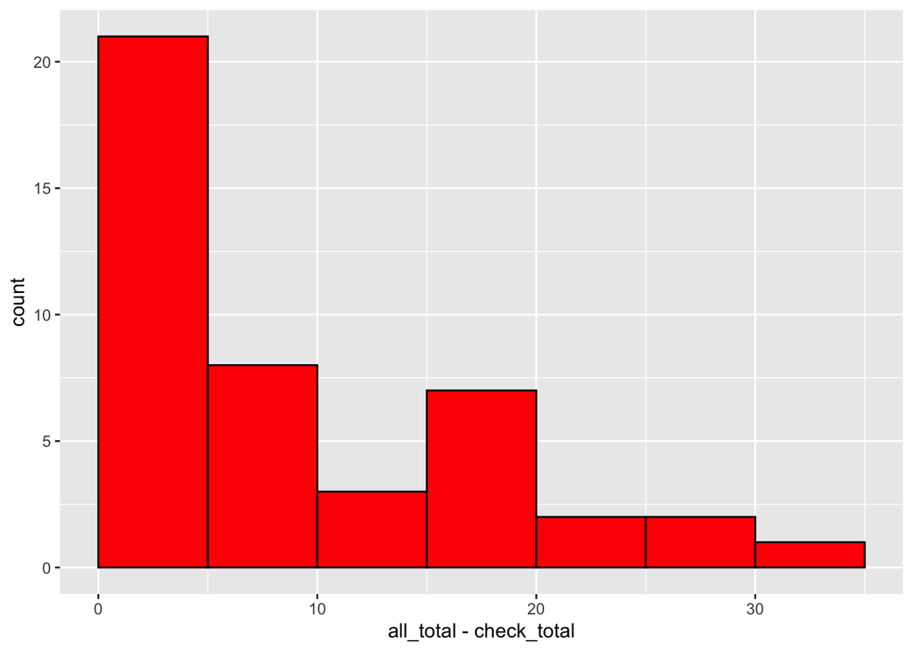

```r
ggplot(table_mismatch, aes(x=all_total - check_total)) +
  geom_histogram(boundary=0, binwidth=5, fill = "red", color = "black")
```

#### Let’s consider another way to check the totals (`all_total`) using `purrr::pmap_dbl()`.

- Our method to sum across columns required naming each column
- This was not too bad with the eight we did, but could get tedious with more
- The **tidyverse** package **purrr** has a number of useful functions for iteration
  - Here, we want to iterate across columns to get a (partial) row sum
- The function `pmap_dbl()` will apply some function row-wise and return a numeric valued column of data
- The first argument to `pmap_dbl()` is a data frame
- As we are not piping into `pmap_dbl()` but instead call it within `mutate()`, we use the symbol `.` to refer to the data frame that was piped into `mutate()`.

```r
## check total in a new way using purrr::pmap_dbl()
## pmap_dbl here takes a data frame as its first argument
##   and then applies the function row-wise to its elements, we will use the `sum()` function
## select() supplies the data frame
## because we do not pipe into select here directly (we're inside of a pipe into mutate),
##   we need to specify the input to select (we need to note which variables we want to sum over)
##   The '.' represents the object that was piped into mutate()
##   To this we select the columns that contain "_n_" and 'all_excluded'
## the row sums of this selected sub-data frame are saved as a new
##   variable named check_total2
awt = awt %>%
  mutate(check_total2 =
           pmap_dbl(select(., contains("_n_"), all_excluded), sum))

## Verify that the check sums match each other
awt %>%
  select(check_total, check_total2) %>% # two variables totaling the passenger counts
  mutate(diff = check_total - check_total2) %>% # take the difference
  summarize(min = min(diff),
            max = max(diff),
            ndiff = sum(diff != 0))
```

```
## # A tibble: 1 × 3
##     min   max ndiff
##   <dbl> <dbl> <int>
## 1     0     0     0
```

```r
## Note that there are no differences
```

- Discrepancies should not have much influence over primary questions of interest.

#### Summary of findings

- The data do not contain any observations on May 8, 2018.
- The `all_total` variable has a few discrepancies where counts differ occasionally when a flight arrival was near midnight.
- We can use `check_total` as the actual value, but this assumes the individual column counts are correct.
- Some correction or ignoring the issue is not likely to make much difference in major questions.

### Associations

- Next we’ll create some graphics to see if we notice any interesting patterns that may lead to some questions we can try to address with the data.

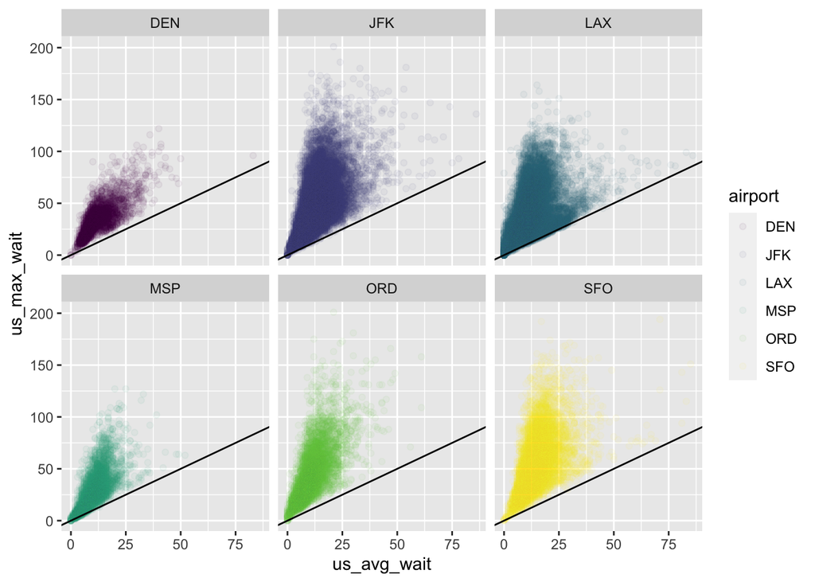

```r
## Compare maximum wait time with average wait time
## For US Citizens
## There are many points, so use a small alpha value to lessen overplotting
ggplot(awt, aes(x=us_avg_wait, y=us_max_wait, color=airport)) +
  geom_point(alpha = 0.05) +
  geom_abline(intercept=0, slope=1) +
  facet_wrap(~airport)
```

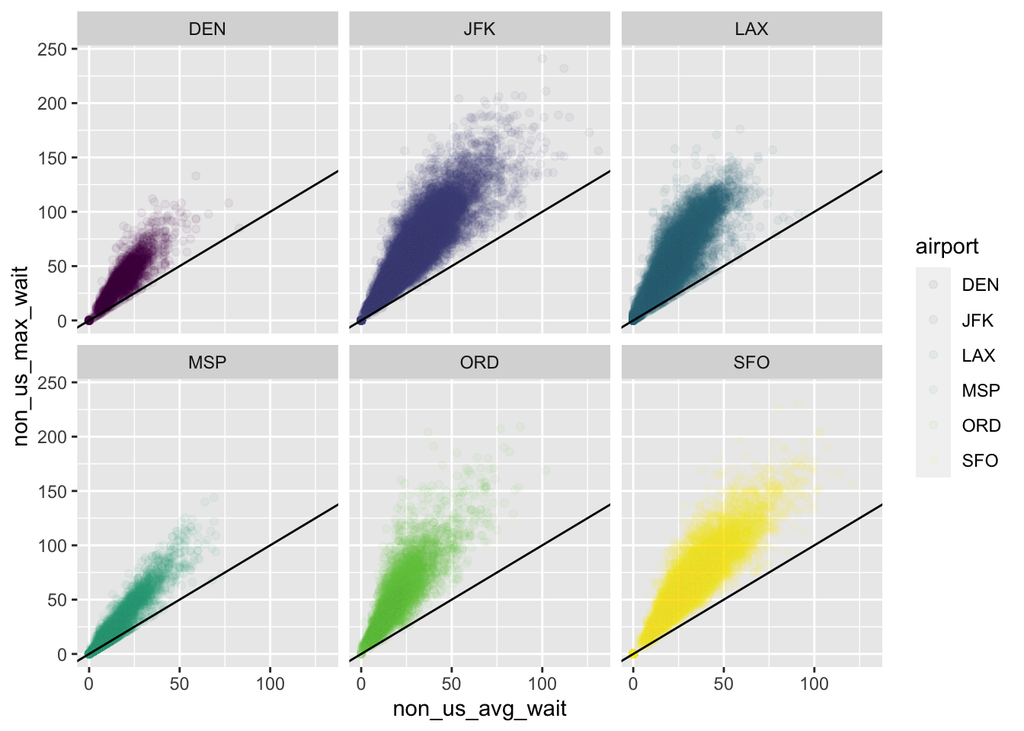

```r
## And for non US Citizens
ggplot(awt, aes(x=non_us_avg_wait, y=non_us_max_wait, color=airport)) +
  geom_point(alpha=0.05) +
  geom_abline(intercept=0, slope=1) +
  facet_wrap(~airport)
```

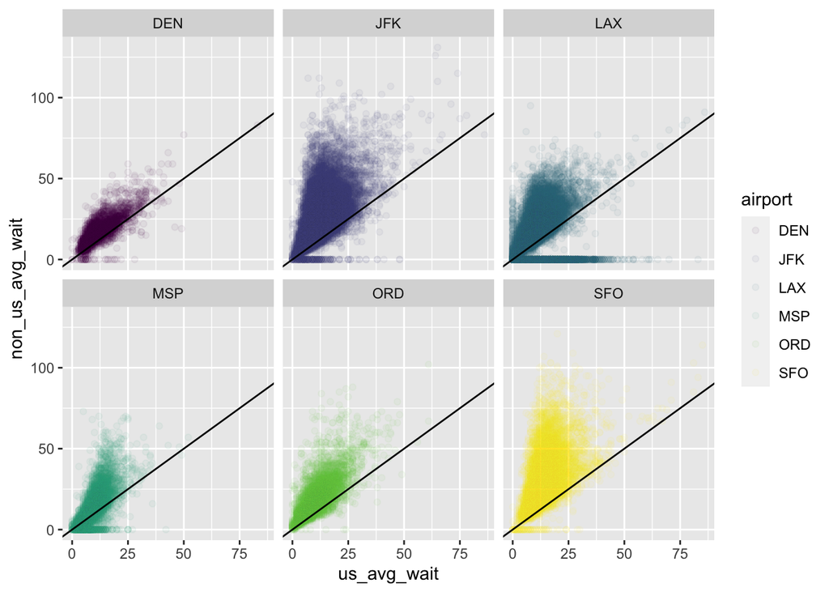

```r
## Compare average wait between US and non US citizens
ggplot(awt, aes(x=us_avg_wait, y=non_us_avg_wait, color=airport)) +
  geom_point(alpha = 0.05) +
  geom_abline(intercept=0, slope=1) +
  facet_wrap(~airport)
```

```r
## It looks like there are some times where there were few or no non-US international travelers
awt %>%
  filter(non_us_avg_wait == 0)
```

```
## # A tibble: 4,241 × 23
##    airport terminal      date       hour        us_avg_wait us_max_wait non_us_avg_wait
##    <chr>   <chr>         <date>     <chr>             <dbl>       <dbl>           <dbl>
##  1 DEN     International 2018-01-02 1600 - 1700          16          24               0
##  2 DEN     International 2018-01-06 1900 - 2000          15          22               0
##  3 DEN     International 2018-01-12 1900 - 2000          19          29               0
##  4 DEN     International 2018-01-13 1900 - 2000          15          21               0
##  5 DEN     International 2018-01-16 1100 - 1200           0           0               0
##  6 DEN     International 2018-01-21 1900 - 2000           5          14               0
##  7 DEN     International 2018-01-23 1800 - 1900          17          28               0
##  8 DEN     International 2018-01-27 1800 - 1900           7          14               0
##  9 DEN     International 2018-02-01 1900 - 2000          16          22               0
## 10 DEN     International 2018-02-14 1900 - 2000          10          16               0
## # … with 4,231 more rows, and 16 more variables: non_us_max_wait <dbl>,
## #   all_avg_wait <dbl>, all_max_wait <dbl>, all_n_0_15 <dbl>,
## #   all_n_16_30 <dbl>, all_n_31_45 <dbl>, all_n_46_60 <dbl>, all_n_61_90 <dbl>,
## #   all_n_91_120 <dbl>, all_n_120_plus <dbl>, all_excluded <dbl>,
## #   all_total <dbl>, all_flights <dbl>, all_booths <dbl>, check_total <dbl>,
## #   check_total2 <dbl>
```